# P7_Classification evaluation_Kyuri

Kyuri Park

November 07, 2022

# Introduction

First, load the packages:

```r
library(MASS)
library(ISLR)
library(tidyverse)

library(pROC)

library(rpart)
library(rpart.plot)
library(randomForest)
```

Set the seed for reproducibility.

```r
set.seed(123)
```

# Confusion matrix, continued

## 1. Create a logistic regression model `lr_mod` for this data using the formula `response ~ .` and create a confusion matrix based on a .5 cutoff probability.

```r
cardio <- read.csv("data/cardiovascular_treatment.csv")

# check data
glimpse(cardio) # data type is not correct
```

```
Rows: 253
Columns: 7
$ severity  <chr> "high", "low", "low", "low", "low", "low", "low", "high", "l…
$ age       <dbl> 54.76957, 59.48023, 55.43236, 48.16994, 54.49713, 40.72455, …
$ gender    <chr> "m", "f", "f", "f", "f", "m", "f", "f", "f", "m", "m", "f", …
$ bb_score  <dbl> 349.51705, 99.74619, 444.73453, 152.69093, 251.40971, 349.12…
$ prior_cvd <int> 0, 0, 0, 0, 1, 0, 0, 1, 0, 0, 1, 0, 2, 0, 0, 0, 0, 1, 1, 0, …
$ dose      <int> 2, 2, 2, 2, 2, 2, 2, 3, 1, 2, 1, 3, 2, 2, 2, 1, 3, 2, 2, 1, …
$ response  <int> 1, 0, 0, 1, 0, 1, 0, 1, 1, 0, 1, 1, 0, 1, 1, 1, 1, 0, 0, 0, …
```

```r
# clean data
cardio <- cardio %>%
  mutate(severity = as.factor(severity),
         gender = as.factor(gender),
         dose = as.factor(dose),
         response = as.factor(response))
```

```r
# fit lr
lr_mod <- glm(response ~ ., family = "binomial", data = cardio)
# predicted probability
prob_lr <- predict(lr_mod, type = "response")
# prediction (cutoff = 0.5)
pred_lr <- ifelse(prob_lr > 0.5, 1, 0)

# confusion matrix
cm_lr <- table(true = cardio$response, prediction = pred_lr); cm_lr
```

```
    prediction
true  0  1
   0 80 47
   1 29 97
```

## 2. Calculate the accuracy, true positive rate (sensitivity), the true negative rate (specificity), the false positive rate, the positive predictive value, and the negative predictive value. You can use the [confusion matrix table on wikipedia](https://en.wikipedia.org/w/index.php?title=Sensitivity_and_specificity&oldid=862159646#Confusion_matrix). What can you say about the model performance? Which metrics are most relevant if this model were to be used in the real world?

```r
# check model performance
TN <- cm_lr[1,1]
TP <- cm_lr[2,2]
FN <- cm_lr[2,1]
FP <- cm_lr[1,2]

data.frame(
ACC = (TP + TN) / sum(cm_lr), # accuracy
TPR = TP / (TN + FN), # sensitivity (TPR)
TNR = TN / (TN + FP), # specificity (TNR)
FPR = FP / (FP + TN), # false positive rate
PPV = TP / (TP + FP), # positive predictive value (precision)
NPV = TN / (TN + FN) # negative predictive value
) %>% round(2)
```

| ACC | TPR | TNR | FPR | PPV | NPV |
| --- | --- | --- | --- | --- | --- |
| 0.7 | 0.89 | 0.63 | 0.37 | 0.67 | 0.73 |

## 3. Create an LDA model `lda_mod` for the same prediction problem. Compare its performance to the LR model.

The performance is almost identical.

```r
lda_mod <- lda(response ~., data = cardio)
pred_lda <- predict(lda_mod)$class

cm_lda <- table(true = cardio$response, predicted = pred_lda); cm_lda
```

```
    predicted
true  0  1
   0 80 47
   1 29 97
```

```r
# check model performance
TN <- cm_lda[1,1]
TP <- cm_lda[2,2]
FN <- cm_lda[2,1]
FP <- cm_lda[1,2]

data.frame(
ACC = (TP + TN) / sum(cm_lda), # accuracy
TPR = TP / (TN + FN), # sensitivity (TPR)
TNR = TN / (TN + FP), # specificity (TNR)
FPR = FP / (FP + TN), # false positive rate = 1 - specificity
PPV = TP / (TP + FP), # positive predictive value (precision)
NPV = TN / (TN + FN) # negative predictive value
) %>% round(2)
```

| ACC | TPR | TNR | FPR | PPV | NPV |
| --- | --- | --- | --- | --- | --- |
| 0.7 | 0.89 | 0.63 | 0.37 | 0.67 | 0.73 |

## 4. Compare the classification performance of `lr_mod` and `lda_mod` for the new patients in the `data/new_patients.csv`.

Again, the performance is almost identical.

```r
# load the new patients data
new_patients <- read.csv("data/new_patients.csv") %>%
  mutate(severity = as.factor(severity),
         gender   = as.factor(gender),
         dose     = as.factor(dose),
         response = as.factor(response))

# predict based on new patients data
## logistic regression
prob_lr_new <- predict(lr_mod, newdata = new_patients, type = "response")
pred_lr_new <- ifelse(prob_lr_new > .5, 1, 0)

## LDA
pred_lda_new <- predict(lda_mod, newdata = new_patients)$class

# confusion matrix
## lr
cmat_lr_new <- table(true = new_patients$response, pred = pred_lr_new); cmat_lr_new
```

```
    pred
true  0  1
   0 16 11
   1  9 14
```

```r
## lda
cmat_lda_new <- table(true = new_patients$response, pred = pred_lda_new); cmat_lda_new
```

```
    pred
true  0  1
   0 16 11
   1  9 14
```

## Calculate the out-of-sample brier score for the `lr_mod` and give an interpretation of this number.

```r
brier_score <- mean((prob_lr_new - (as.numeric(new_patients$response) - 1)) ^ 2); brier_score
```

```
[1] 0.2283307
```

The lower the Brier score is for a set of predictions, the better the predictions are calibrated. In this case, the brier score is 0.23, which is not too high.

## 5. Create two LR models: `lr1_mod` with `severity`, `age`, and `bb_score` as predictors, and `lr2_mod` with the formula `response ~ age + I(age^2) + gender + bb_score * prior_cvd * dose`. Save the predicted probabilities on the training data.

```r
lr1_mod <- glm(response ~ severity + bb_score + age,
               family = "binomial", data = cardio)
prob_lr1 <- predict(lr1_mod, type = "response")

lr2_mod <- glm(response ~ age + I(age^2) + gender + bb_score * prior_cvd * dose,
               family = "binomial", data = cardio)
prob_lr2 <- predict(lr2_mod, type = "response")
```

## 6. Use the function `roc()` from the `pROC` package to create two ROC objects with the predicted probabilities: `roc_lr1` and `roc_lr2`. Use the `ggroc()` method on these objects to create an ROC curve plot for each. Which model performs better? Why?

Model 2 is better as both sensitivity and specificity are higher across the whole range.

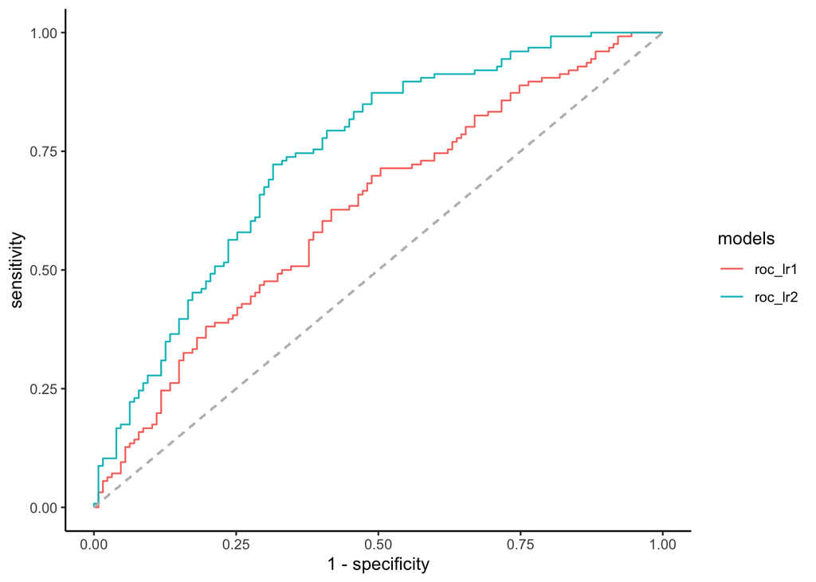

```r
roc_lr1 <- roc(cardio$response, prob_lr1)
#roc_lr1$thresholds
roc_lr2 <- roc(cardio$response, prob_lr2)


ggroc(list(roc_lr1, roc_lr2), legacy.axes = TRUE, aes=c("color")) +
  # diagonal line
  geom_segment(aes(x = 0, xend = 1, y = 0, yend = 1), color="grey", linetype="dashed") +
  scale_color_discrete(labels = c("roc_lr1", "roc_lr2")) +
  theme_classic() + labs(color = "models")
```

## 7. Print the `roc_lr1` and `roc_lr2` objects. Which AUC value is higher? How does this relate to the plots you made before? What is the minimum AUC value and what would a “perfect” AUC value be and how would it look in a plot?

AUC of `roc_lr2` is higher (0.74) than AUC of `roc_lr1` (0.63). Perfect AUC would be 1, which has specificity of 1 as well as sensitivity of 1 (see the plot below).

```r
roc_lr1; roc_lr2
```

```
Call:
roc.default(response = cardio$response, predictor = prob_lr1)

Data: prob_lr1 in 127 controls (cardio$response 0) < 126 cases (cardio$response 1).
Area under the curve: 0.6253
```

```
Call:
roc.default(response = cardio$response, predictor = prob_lr2)

Data: prob_lr2 in 127 controls (cardio$response 0) < 126 cases (cardio$response 1).
Area under the curve: 0.7405
```

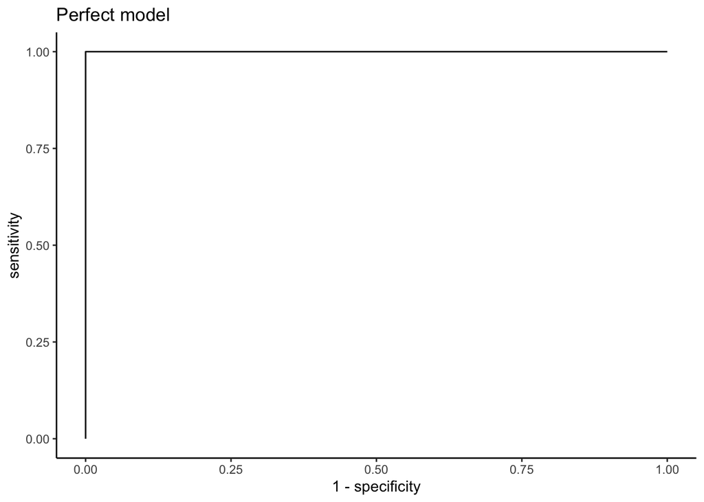

```r
# perfect AUC
ggplot(data.frame(x = c(0, 0, 1), y = c(0, 1, 1)),
       aes(x = x, y = y)) +
  geom_line() +
  labs(y = "sensitivity",
       x = "1 - specificity",
       title = "Perfect model") +
  theme_classic()
```

# Iris dataset

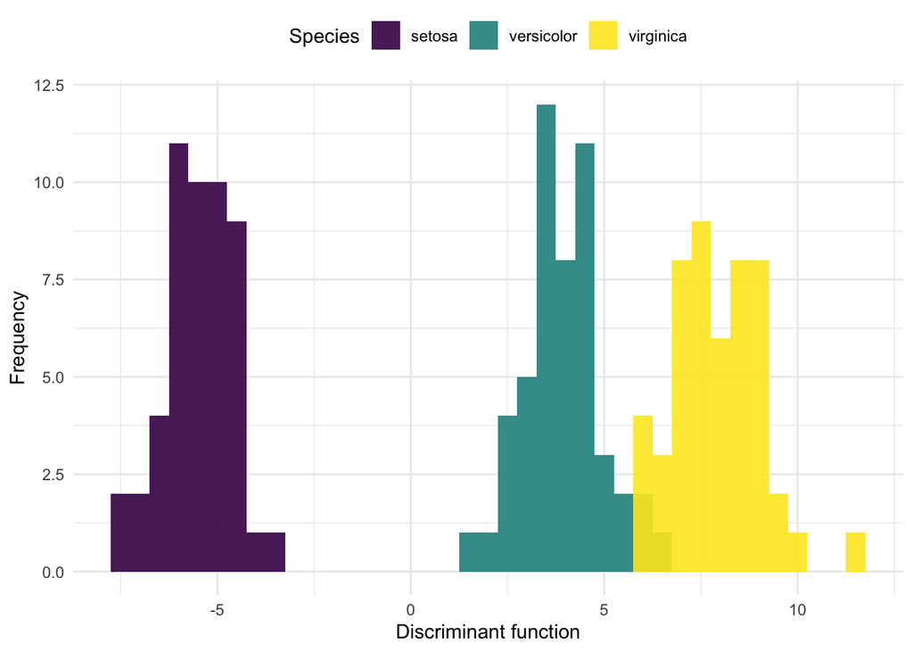

```r
# fit lda model, i.e. calculate model parameters
lda_iris <- lda(Species ~ ., data = iris)

# use those parameters to compute the first linear discriminant
first_ld <- -c(as.matrix(iris[, -5]) %*% lda_iris$scaling[,1])

# plot
tibble(
  ld = first_ld,
  Species = iris$Species
) %>%
  ggplot(aes(x = ld, fill = Species)) +
  geom_histogram(binwidth = .5, position = "identity", alpha = .9) +
  scale_fill_viridis_d() +
  theme_minimal() +
  labs(
    x = "Discriminant function",
    y = "Frequency",
    main = "Fisher's linear discriminant function on Iris species"
  ) +
  theme(legend.position = "top")
```

## 8. Explore the iris dataset using summaries and plots.

```r
summary(iris)
```

```
  Sepal.Length    Sepal.Width     Petal.Length    Petal.Width
 Min.   :4.300   Min.   :2.000   Min.   :1.000   Min.   :0.100
 1st Qu.:5.100   1st Qu.:2.800   1st Qu.:1.600   1st Qu.:0.300
 Median :5.800   Median :3.000   Median :4.350   Median :1.300
 Mean   :5.843   Mean   :3.057   Mean   :3.758   Mean   :1.199
 3rd Qu.:6.400   3rd Qu.:3.300   3rd Qu.:5.100   3rd Qu.:1.800
 Max.   :7.900   Max.   :4.400   Max.   :6.900   Max.   :2.500
       Species
 setosa    :50
 versicolor:50
 virginica :50
```

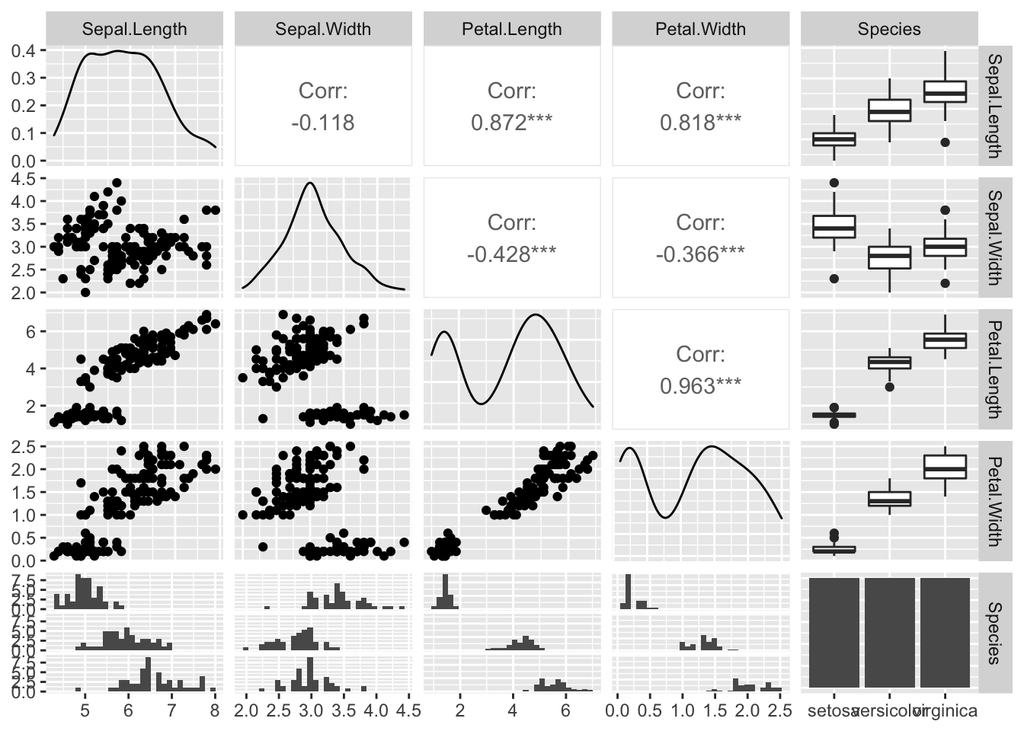

```r
library(GGally)
ggpairs(iris)
```

## 9. Fit an additional LDA model, but this time with only `Sepal.Length` and `Sepal.Width` as predictors. Call this model `lda_iris_sepal`.

```r
lda_iris_sepal <- lda(Species ~ Sepal.Length + Sepal.Width, data = iris)
```

## 10. Create a confusion matrix of the `lda_iris` and `lda_iris_sepal` models. (NB: we did not split the dataset into training and test set, so use the training dataset to generate the predictions.). Which performs better in terms of accuracy?

cm_iris performs better!

```r
cm_iris <- table(true = iris$Species, predicted = predict(lda_iris)$class)
cm_sepal <- table(true = iris$Species, predicted = predict(lda_iris_sepal)$class)

cm_iris; cm_sepal
```

```
            predicted
true         setosa versicolor virginica
  setosa         50          0         0
  versicolor      0         48         2
  virginica       0          1        49
```

```
            predicted
true         setosa versicolor virginica
  setosa         49          1         0
  versicolor      0         36        14
  virginica       0         15        35
```

# Classification trees

Classification trees in `R` can be fit using the `rpart()` function.

## 11. Use `rpart()` to create a classification tree for the `Species` of `iris`. Call this model `iris_tree_mod`. Plot this model using `rpart.plot()`.

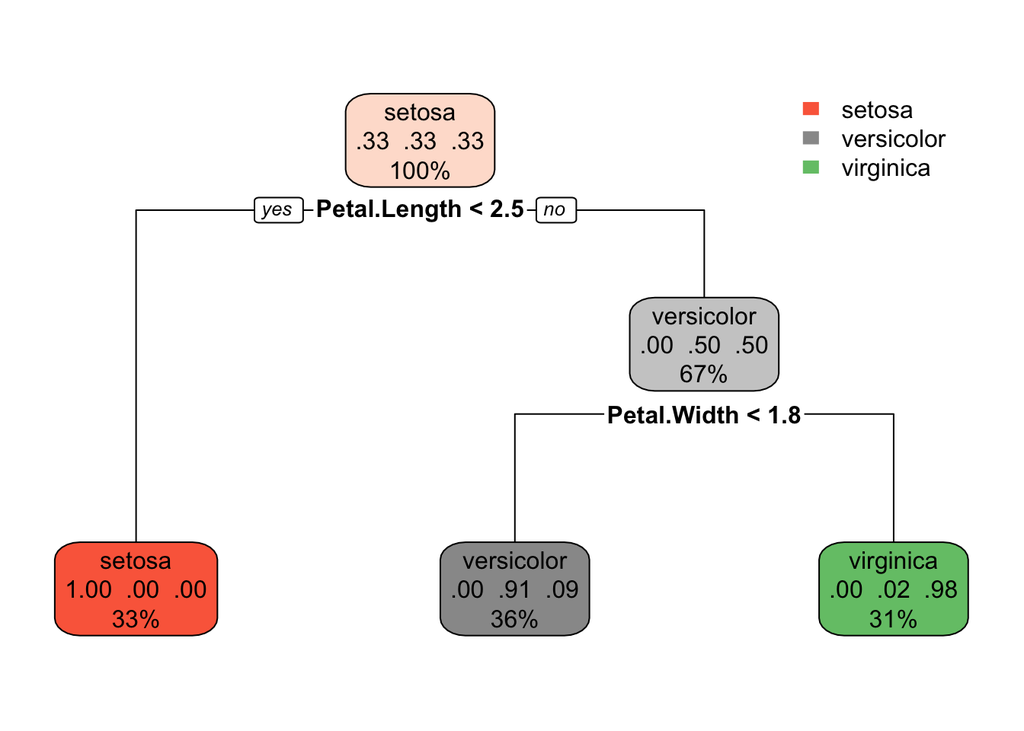

```r
iris_tree_mod <- rpart(Species ~., data = iris)
rpart.plot(iris_tree_mod)
```

## 12. How would an iris with 2.7 cm long and 1.5 cm wide petals be classified?

Will be classified as `versicolor` according to the tree.

## 13. Create a scatterplot where you map `Petal.Length` to the x position and `Petal.Width` to the y position. Then, manually add a vertical and a horizontal line (using `geom_segment`) at the locations of the splits from the classification tree. Interpret this plot.

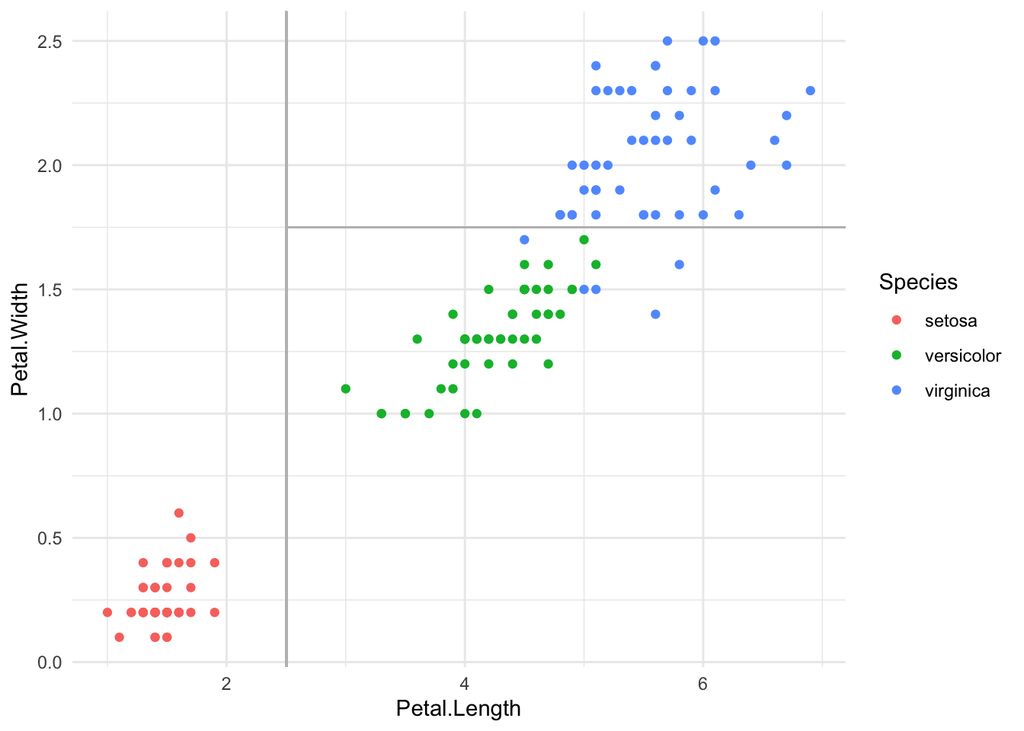

```r
iris %>%
ggplot(aes(x = Petal.Length, y = Petal.Width, color= Species)) +
  geom_point() +
  geom_segment(aes(x = 2.5, xend = 2.5, y = -Inf, yend = Inf),
               color = "gray") +
  geom_segment(aes(x = 2.5, xend = Inf, y = 1.75, yend = 1.75),
               color = "gray") +
  theme_minimal()
```

```r
# check the control parameters
?rpart.control
```

## 14. Create a classification tree model where the splits continue until all the observations have been classified. Call this model `iris_tree_full_mod`. Plot this model using `rpart.plot()`. Do you expect this model to perform better or worse on new Irises?

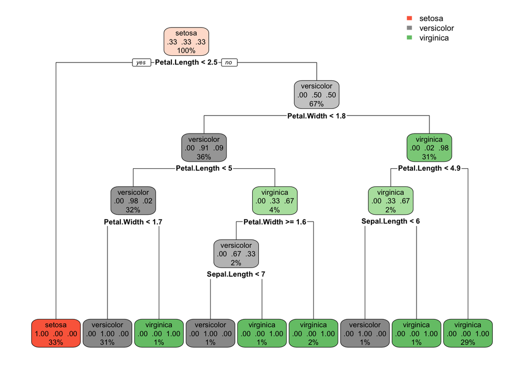

```r
iris_tree_full_mod <- rpart(Species ~., data = iris, control = rpart.control(minsplit =1, cp= 0))
rpart.plot(iris_tree_full_mod)
```

# Final assignment: Random forest for classification

## 15. Use the function `randomForest()` to create a random forest model on the iris dataset. Use the function `importance()` on this model and create a bar plot of variable importance. Does this agree with your expectations? How well does the random forest model perform compared to the `lda_iris` model?

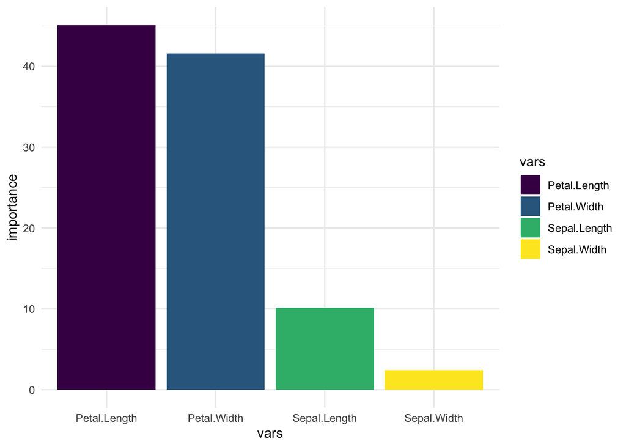

```r
# randomforest model
rf_mod <- randomForest(Species ~ ., data = iris)
# variable importance
var_imp <- importance(rf_mod)

var_imp %>% as.data.frame() %>%
  transmute(vars = rownames(.), importance = .[,1]) %>%
  ggplot(aes(x = vars, y = importance, fill = vars)) +
  geom_col() +
  scale_fill_viridis_d() +
  theme_minimal()
```